# Lab 10 - Vanilla CNN and Fine-Tune VGG16 - for Dogs and Cats Classification

# 8978659

## 1 Obtain the Data: Get the Dogs vs Cats dataset

```python
import os
import random
import shutil
import tensorflow as tf
from tensorflow.keras.preprocessing.image import ImageDataGenerator
from tensorflow.keras.applications import VGG16
from tensorflow.keras.layers import Flatten, Dense, Dropout
from tensorflow.keras.models import Model
from tensorflow.keras.optimizers import RMSprop

from tensorflow import keras
from tensorflow.keras import layers
import pathlib
from tensorflow.keras.utils import image_dataset_from_directory

import pandas as pd
import pathlib
from pathlib import Path

import numpy as np
import pandas as pd

# plotting modules
from matplotlib import pyplot as plt


from sklearn.model_selection import train_test_split




from tensorflow import keras
from tensorflow.keras import layers

import tensorflow as tf
from keras.utils import to_categorical
from keras.models import load_model


from tensorflow.keras.models import Sequential
from keras.callbacks import ModelCheckpoint
from tensorflow.keras.layers import Dense
from sklearn.metrics import accuracy_score, precision_score, recall_score, f1_score, confusion_matrix, classification_report, precision_recall_curve, ConfusionMatrixDisplay
```

```python
import os, shutil, pathlib

new_base_dir = pathlib.Path("C:/Users/Riddhi/Downloads/AssignmentLab9/data/kaggle_dogs_vs_cats_small")
```

```python
train_dataset = image_dataset_from_directory(
    new_base_dir / "train",
    image_size=(180, 180),
    batch_size=32)
validation_dataset = image_dataset_from_directory(
    new_base_dir / "validation",
    image_size=(180, 180),
    batch_size=32)
test_dataset = image_dataset_from_directory(
    new_base_dir/ "test",
    image_size=(180, 180),
    batch_size=32)
```

```
Found 2000 files belonging to 2 classes.
Found 1000 files belonging to 2 classes.
Found 2000 files belonging to 2 classes.
```

```python
test_dataset
```

```
<_PrefetchDataset element_spec=(TensorSpec(shape=(None, 180, 180, 3), dtype=tf.float32, name=None), TensorSpec(shape=(None,), dtype=tf.int32, name=None))>
```

```python
conv_base = keras.applications.vgg16.VGG16(
    weights="imagenet",
    include_top=False,
    input_shape=(180, 180, 3))
```

```python
import numpy as np

def get_features_and_labels(dataset):
    # Initialize lists to store features and labels
    all_features = []
    all_labels = []

    # Iterate through the dataset
    for images, labels in dataset:
        # Preprocess the images using VGG16 preprocessing function
        preprocessed_images = keras.applications.vgg16.preprocess_input(images)

        # Extract features using the pre-trained VGG16 model (conv_base)
        features = conv_base.predict(preprocessed_images)

        # Append features and labels to the respective lists
        all_features.append(features)
        all_labels.append(labels)

    # Concatenate all features and labels
    return np.concatenate(all_features), np.concatenate(all_labels)

# Get features and labels for training dataset
train_features, train_labels =  get_features_and_labels(train_dataset)

# Get features and labels for validation dataset
validation_features, validation_labels =  get_features_and_labels(validation_dataset)

# Get features and labels for test dataset
test_features, test_labels = get_features_and_labels(test_dataset)
```

[output not shown]

[output cut: 104 more lines]

[output not shown]

```python
train_features.shape, validation_features.shape, test_features.shape
```

```
((2000, 5, 5, 512), (1000, 5, 5, 512), (2000, 5, 5, 512))
```

```python
train_labels
```

```
array([1, 1, 1, ..., 1, 1, 1])
```

## 2 EDA: Explore the data with relevant graphs, statistics and insights

```python
pip install seaborn
```

[output not shown]

```python
import pandas as pd
from pathlib import Path

def create_image_dataframe(base_folder, dataset_type):
    """
    Create a DataFrame containing image paths, image names, and labels.

    Args:
    - base_folder (Path): The base directory containing the dataset.
    - dataset_type (str): The type of dataset ('train', 'validation', or 'test').

    Returns:
    - df (DataFrame): DataFrame containing image information.
    """
    # Initialize a list to store the information
    data = []
    dataset_folder = base_folder / dataset_type  # e.g., 'train', 'validation', 'test'

    # Iterate through each subfolder ('cat' and 'dog') in the given directory
    for subfolder in ['cat', 'dog']:
        full_subfolder_path = dataset_folder / subfolder

        # Iterate through each image file in the subfolder
        for image_path in full_subfolder_path.glob('*.jpg'):
            # Construct a concise relative path in the format "train/cat"
            concise_path = f"{dataset_type}/{subfolder}/{image_path.name}"

            # Extract the image name (file name without the extension)
            image_name = image_path.stem

            # The label is determined by the subfolder name
            label = subfolder

            # Append the information to the list
            data.append({'ImagePath': concise_path, 'ImageName': image_name, 'Label': label})

    # Create a DataFrame from the list
    return pd.DataFrame(data)

# Define the base path for the data
new_base_dir = Path('C:/Users/Riddhi/Downloads/AssignmentLab9//data/dogs-vs-cats-small')

# Create DataFrames for train, validation, and test sets
df_train = create_image_dataframe(new_base_dir, 'train')
df_validation = create_image_dataframe(new_base_dir, 'validation')
df_test = create_image_dataframe(new_base_dir, 'test')

# Display the first few rows of each DataFrame as a sanity check
print("Training Set:")
display(df_train.head())

print("\nValidation Set:")
display(df_validation.head())

print("\nTest Set:")
display(df_test.head())
```

```
Training Set:
```

```
Validation Set:
```

```
Test Set:
```

```
Exploratory Data Analysis for Training Dataset:
Features shape: (2000, 5, 5, 512)
Labels shape: (2000,)
```

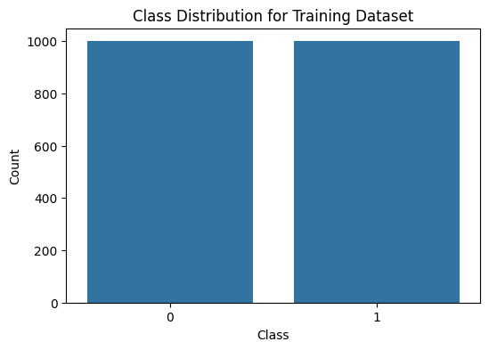

```
Exploratory Data Analysis for Validation Dataset:
Features shape: (1000, 5, 5, 512)
Labels shape: (1000,)
```

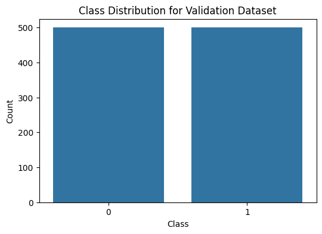

```
Exploratory Data Analysis for Test Dataset:
Features shape: (2000, 5, 5, 512)
Labels shape: (2000,)
```

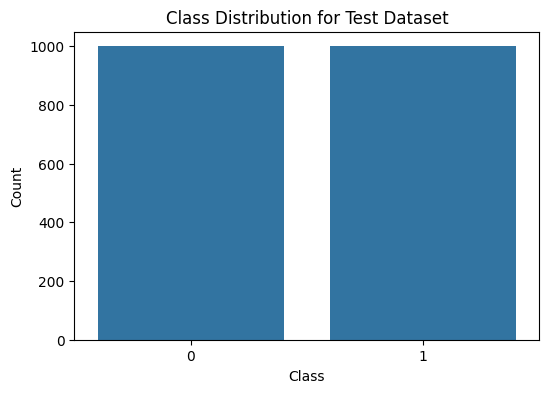

```python
# Import necessary libraries
import matplotlib.pyplot as plt
import seaborn as sns  # Add this line to import seaborn

# Function to perform EDA on the dataset
def perform_eda(features, labels, dataset_name):
    # Print the dataset name
    print(f"Exploratory Data Analysis for {dataset_name}:")

    # Print the shape of features and labels
    print(f"Features shape: {features.shape}")
    print(f"Labels shape: {labels.shape}")

    # Plot class distribution
    plt.figure(figsize=(6, 4))
    sns.countplot(x=labels)
    plt.title(f'Class Distribution for {dataset_name}')
    plt.xlabel('Class')
    plt.ylabel('Count')
    plt.show()

# Perform EDA on training dataset
perform_eda(train_features, train_labels, 'Training Dataset')

# Perform EDA on validation dataset
perform_eda(validation_features, validation_labels, 'Validation Dataset')

# Perform EDA on test dataset
perform_eda(test_features, test_labels, 'Test Dataset')
```

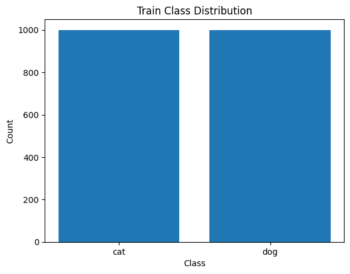

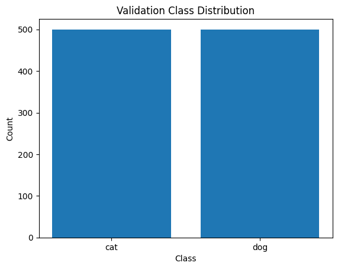

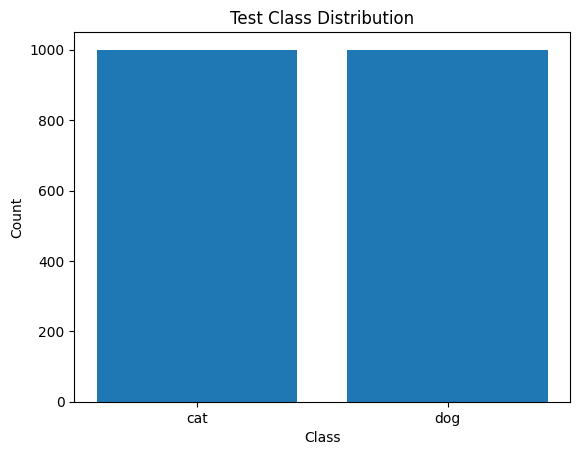

```python
import os
import matplotlib.pyplot as plt
import random

def plot_class_distribution(dataset, dataset_name):
    class_names = dataset.class_names
    class_counts = [0] * len(class_names)
    for _, labels in dataset:
        for label in labels:
            class_counts[label] += 1
    plt.bar(class_names, class_counts)
    plt.xlabel('Class')
    plt.ylabel('Count')
    plt.title(f'{dataset_name} Class Distribution')
    plt.show()

# Plot class distribution for each dataset
datasets = [(train_dataset, "Train"), (validation_dataset, "Validation"), (test_dataset, "Test")]

for dataset, dataset_name in datasets:
    plot_class_distribution(dataset, dataset_name)
```

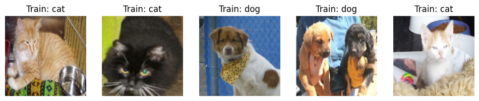

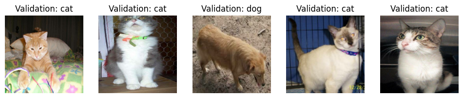

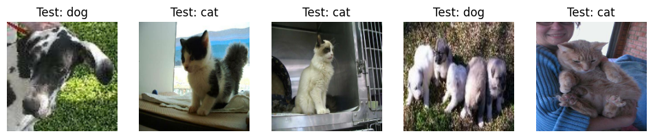

```python
# Function to plot sample images
def plot_sample_images(dataset, dataset_name, num_samples=5):
    class_names = dataset.class_names

    plt.figure(figsize=(12, 6))

    for images, labels in dataset.take(1):
        for i in range(num_samples):
            plt.subplot(1, num_samples, i+1)
            plt.imshow(images[i].numpy().astype("uint8"))
            plt.title(f'{dataset_name}: {class_names[labels[i]]}')
            plt.axis("off")

    plt.show()

# Display sample images for each dataset
for dataset, dataset_name in datasets:
    plot_sample_images(dataset, dataset_name)
```

### Display basic statics

```python
pip install plotly
```

[output not shown]

[output cut: 109 more lines]

[output not shown]

```python
# Function to display basic statistics of a dataset
def display_basic_statistics(dataset, dataset_name):
    # Extract class names from the dataset
    class_names = dataset.class_names

    # Initialize a dictionary to store the count of each class
    class_counts = {class_name: 0 for class_name in class_names}

    # Initialize a variable to store the total number of samples
    total_samples = 0

    # Iterate over the dataset to count the occurrences of each class
    for _, labels in dataset:
        for label in labels.numpy():
            class_counts[class_names[label]] += 1
            total_samples += 1

    # Display the basic statistics
    print(f"{dataset_name} Basic Statistics:")
    print("Total samples:", total_samples)

    # Display the count of each class
    for class_name, count in class_counts.items():
        print(f"Number of {class_name} images:", count)
    print()

# Display basic statistics for each dataset
for dataset, dataset_name in datasets:
    display_basic_statistics(dataset, dataset_name)
```

```
Train Basic Statistics:
Total samples: 2000
Number of cat images: 1000
Number of dog images: 1000

Validation Basic Statistics:
Total samples: 1000
Number of cat images: 500
Number of dog images: 500

Test Basic Statistics:
Total samples: 2000
Number of cat images: 1000
Number of dog images: 1000
```

## FIT THE MODELS

### MODEL 1

```python
# Importing necessary libraries from TensorFlow
import tensorflow as tf
from tensorflow import keras
from tensorflow.keras import layers

# Define the input layer with a shape of (5, 5, 512)
inputs = keras.Input(shape=(5, 5, 512))

# Flatten the input layer
x = layers.Flatten()(inputs)

# Add a dense layer with 256 units
x = layers.Dense(256)(x)

# Apply dropout regularization with a rate of 0.5
x = layers.Dropout(0.5)(x)

# Define the output layer with a single unit and sigmoid activation for binary classification
outputs = layers.Dense(1, activation="sigmoid")(x)

# Create the model using the defined input and output layers
model_1 = keras.Model(inputs, outputs)
```

```python
model_1.summary()
```

```
Model: "functional_121"
```

```
┏━━━━━━━━━━━━━━━━━━━━━━━━━━━━━━━━━┳━━━━━━━━━━━━━━━━━━━━━━━━┳━━━━━━━━━━━━━━━┓
┃ Layer (type)                    ┃ Output Shape           ┃       Param # ┃
┡━━━━━━━━━━━━━━━━━━━━━━━━━━━━━━━━━╇━━━━━━━━━━━━━━━━━━━━━━━━╇━━━━━━━━━━━━━━━┩
│ input_layer_71 (InputLayer)     │ (None, 5, 5, 512)      │             0 │
├─────────────────────────────────┼────────────────────────┼───────────────┤
│ flatten_50 (Flatten)            │ (None, 12800)          │             0 │
├─────────────────────────────────┼────────────────────────┼───────────────┤
│ dense_81 (Dense)                │ (None, 256)            │     3,277,056 │
├─────────────────────────────────┼────────────────────────┼───────────────┤
│ dropout_38 (Dropout)            │ (None, 256)            │             0 │
├─────────────────────────────────┼────────────────────────┼───────────────┤
│ dense_82 (Dense)                │ (None, 1)              │           257 │
└─────────────────────────────────┴────────────────────────┴───────────────┘
```

```
 Total params: 3,277,313 (12.50 MB)
```

```
 Trainable params: 3,277,313 (12.50 MB)
```

```
 Non-trainable params: 0 (0.00 B)
```

```python
# Compile the model with binary crossentropy loss, RMSprop optimizer, and accuracy metric
model_1.compile(loss="binary_crossentropy",  # Use binary crossentropy loss for binary classification
                optimizer="rmsprop",  # Use RMSprop optimizer
                metrics=["accuracy"])  # Track accuracy metric during training
```

```python
# Compile the model with binary crossentropy loss, RMSprop optimizer, and accuracy metric
model_1.compile(loss="binary_crossentropy",  # Use binary crossentropy loss for binary classification
                optimizer="rmsprop",  # Use RMSprop optimizer
                metrics=["accuracy"])  # Track accuracy metric during training

# Define a callback to save the best model during training
callbacks = [
    keras.callbacks.ModelCheckpoint(
      filepath="./models/vanilla.keras",  # Filepath to save the best model
      save_best_only=True,  # Save only the best model
      monitor="validation_loss")  # Monitor validation loss to determine the best model
]

# Train the model with training features and labels, using validation data for validation
history_1 = model_1.fit(
    train_features, train_labels,  # Training features and labels
    epochs=30,  # Number of epochs for training
    validation_data=(validation_features, validation_labels),  # Validation data
    callbacks=callbacks)  # Use callbacks during training
```

```
63/63 ━━━━━━━━━━━━━━━━━━━━ 6s 55ms/step - accuracy: 0.9999 - loss: 0.0017 - val_accuracy: 0.9660 - val_loss: 9.4872
63/63 ━━━━━━━━━━━━━━━━━━━━ 3s 40ms/step - accuracy: 0.9998 - loss: 0.0096 - val_accuracy: 0.9730 - val_loss: 6.2449
63/63 ━━━━━━━━━━━━━━━━━━━━ 2s 38ms/step - accuracy: 0.9999 - loss: 0.0218 - val_accuracy: 0.9750 - val_loss: 6.3959
63/63 ━━━━━━━━━━━━━━━━━━━━ 2s 39ms/step - accuracy: 1.0000 - loss: 0.0000e+00 - val_accuracy: 0.9750 - val_loss: 6.3959
63/63 ━━━━━━━━━━━━━━━━━━━━ 2s 37ms/step - accuracy: 0.9998 - loss: 0.0114 - val_accuracy: 0.9770 - val_loss: 5.9393
63/63 ━━━━━━━━━━━━━━━━━━━━ 3s 40ms/step - accuracy: 1.0000 - loss: 2.2419e-15 - val_accuracy: 0.9770 - val_loss: 5.9393
63/63 ━━━━━━━━━━━━━━━━━━━━ 3s 42ms/step - accuracy: 1.0000 - loss: 0.0000e+00 - val_accuracy: 0.9770 - val_loss: 5.9393
63/63 ━━━━━━━━━━━━━━━━━━━━ 2s 38ms/step - accuracy: 1.0000 - loss: 1.1756e-15 - val_accuracy: 0.9770 - val_loss: 5.9393
63/63 ━━━━━━━━━━━━━━━━━━━━ 3s 44ms/step - accuracy: 1.0000 - loss: 2.9468e-34 - val_accuracy: 0.9770 - val_loss: 5.9393
63/63 ━━━━━━━━━━━━━━━━━━━━ 3s 46ms/step - accuracy: 1.0000 - loss: 4.7845e-39 - val_accuracy: 0.9770 - val_loss: 5.9393
63/63 ━━━━━━━━━━━━━━━━━━━━ 3s 46ms/step - accuracy: 1.0000 - loss: 4.1861e-30 - val_accuracy: 0.9770 - val_loss: 5.9393
63/63 ━━━━━━━━━━━━━━━━━━━━ 3s 42ms/step - accuracy: 1.0000 - loss: 0.0000e+00 - val_accuracy: 0.9770 - val_loss: 5.9393
63/63 ━━━━━━━━━━━━━━━━━━━━ 3s 45ms/step - accuracy: 1.0000 - loss: 4.7262e-17 - val_accuracy: 0.9770 - val_loss: 5.9393
63/63 ━━━━━━━━━━━━━━━━━━━━ 3s 44ms/step - accuracy: 1.0000 - loss: 4.0083e-28 - val_accuracy: 0.9770 - val_loss: 5.9393
63/63 ━━━━━━━━━━━━━━━━━━━━ 3s 44ms/step - accuracy: 1.0000 - loss: 4.7086e-30 - val_accuracy: 0.9770 - val_loss: 5.9393
63/63 ━━━━━━━━━━━━━━━━━━━━ 3s 46ms/step - accuracy: 1.0000 - loss: 3.8652e-34 - val_accuracy: 0.9770 - val_loss: 5.9393
63/63 ━━━━━━━━━━━━━━━━━━━━ 2s 39ms/step - accuracy: 1.0000 - loss: 0.0000e+00 - val_accuracy: 0.9770 - val_loss: 5.9393
63/63 ━━━━━━━━━━━━━━━━━━━━ 3s 43ms/step - accuracy: 1.0000 - loss: 5.8801e-31 - val_accuracy: 0.9770 - val_loss: 5.9393
63/63 ━━━━━━━━━━━━━━━━━━━━ 3s 46ms/step - accuracy: 0.9999 - loss: 0.0028 - val_accuracy: 0.9750 - val_loss: 7.3216
63/63 ━━━━━━━━━━━━━━━━━━━━ 3s 47ms/step - accuracy: 1.0000 - loss: 1.6142e-04 - val_accuracy: 0.9730 - val_loss: 6.8061
63/63 ━━━━━━━━━━━━━━━━━━━━ 3s 48ms/step - accuracy: 1.0000 - loss: 0.0000e+00 - val_accuracy: 0.9730 - val_loss: 6.8061
63/63 ━━━━━━━━━━━━━━━━━━━━ 3s 43ms/step - accuracy: 1.0000 - loss: 0.0000e+00 - val_accuracy: 0.9730 - val_loss: 6.8061
63/63 ━━━━━━━━━━━━━━━━━━━━ 3s 45ms/step - accuracy: 1.0000 - loss: 5.0505e-08 - val_accuracy: 0.9740 - val_loss: 6.6740
63/63 ━━━━━━━━━━━━━━━━━━━━ 3s 44ms/step - accuracy: 1.0000 - loss: 0.0000e+00 - val_accuracy: 0.9740 - val_loss: 6.6740
63/63 ━━━━━━━━━━━━━━━━━━━━ 3s 44ms/step - accuracy: 0.9987 - loss: 0.0471 - val_accuracy: 0.9750 - val_loss: 5.8434
63/63 ━━━━━━━━━━━━━━━━━━━━ 3s 44ms/step - accuracy: 1.0000 - loss: 4.8751e-31 - val_accuracy: 0.9750 - val_loss: 5.8434
63/63 ━━━━━━━━━━━━━━━━━━━━ 3s 43ms/step - accuracy: 1.0000 - loss: 3.8045e-31 - val_accuracy: 0.9750 - val_loss: 5.8434
63/63 ━━━━━━━━━━━━━━━━━━━━ 3s 43ms/step - accuracy: 1.0000 - loss: 0.0000e+00 - val_accuracy: 0.9750 - val_loss: 5.8434
63/63 ━━━━━━━━━━━━━━━━━━━━ 3s 43ms/step - accuracy: 1.0000 - loss: 4.9279e-32 - val_accuracy: 0.9750 - val_loss: 5.8434
63/63 ━━━━━━━━━━━━━━━━━━━━ 3s 44ms/step - accuracy: 1.0000 - loss: 0.0000e+00 - val_accuracy: 0.9750 - val_loss: 5.8434
```

```python
pip install pandas
```

[output not shown]

[output cut: 35 more lines]

[output not shown]

```python
import pandas as pd

history_df = pd.DataFrame(history_1.history)
history_df.insert(0, 'epoch', range(1, len(history_df) + 1))
history_df
```

[output not shown]

## Displaying curves of loss and accuracy during training

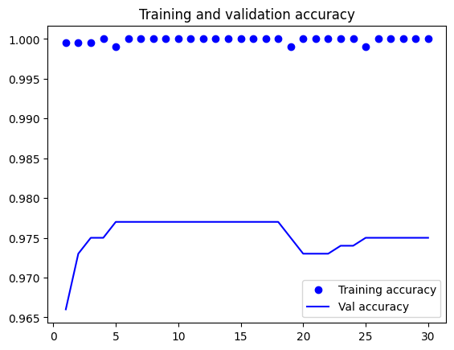

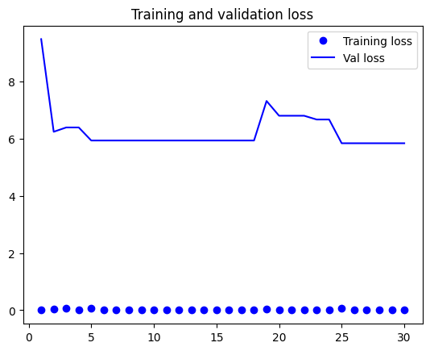

```python
accuracy = history_1.history["accuracy"]
val_accuracy = history_1.history["val_accuracy"]
loss = history_1.history["loss"]
val_loss = history_1.history["val_loss"]
epochs = range(1, len(accuracy) + 1)
plt.plot(epochs, accuracy, "bo", label="Training accuracy")
plt.plot(epochs, val_accuracy, "b", label="Val accuracy")
plt.title("Training and validation accuracy")
plt.legend()
plt.figure()
plt.plot(epochs, loss, "bo", label="Training loss")
plt.plot(epochs, val_loss, "b", label="Val loss")
plt.title("Training and validation loss")
plt.legend()
plt.show()
```

### Evaluating the model on the test set

```python
best_model_1 = keras.models.load_model(
    "./models/vanilla.keras")
test_loss, test_acc = best_model_1.evaluate(x=test_features, y=test_labels)
print(f"Test accuracy: {test_acc:.3f}")
```

```
63/63 ━━━━━━━━━━━━━━━━━━━━ 1s 4ms/step - accuracy: 0.9743 - loss: 5.0903
Test accuracy: 0.974
```

```python
best_model_1.summary()
```

```
Model: "functional_121"
```

```
┏━━━━━━━━━━━━━━━━━━━━━━━━━━━━━━━━━┳━━━━━━━━━━━━━━━━━━━━━━━━┳━━━━━━━━━━━━━━━┓
┃ Layer (type)                    ┃ Output Shape           ┃       Param # ┃
┡━━━━━━━━━━━━━━━━━━━━━━━━━━━━━━━━━╇━━━━━━━━━━━━━━━━━━━━━━━━╇━━━━━━━━━━━━━━━┩
│ input_layer_71 (InputLayer)     │ (None, 5, 5, 512)      │             0 │
├─────────────────────────────────┼────────────────────────┼───────────────┤
│ flatten_50 (Flatten)            │ (None, 12800)          │             0 │
├─────────────────────────────────┼────────────────────────┼───────────────┤
│ dense_81 (Dense)                │ (None, 256)            │     3,277,056 │
├─────────────────────────────────┼────────────────────────┼───────────────┤
│ dropout_38 (Dropout)            │ (None, 256)            │             0 │
├─────────────────────────────────┼────────────────────────┼───────────────┤
│ dense_82 (Dense)                │ (None, 1)              │           257 │
└─────────────────────────────────┴────────────────────────┴───────────────┘
```

```
 Total params: 6,554,628 (25.00 MB)
```

```
 Trainable params: 3,277,313 (12.50 MB)
```

```
 Non-trainable params: 0 (0.00 B)
```

```
 Optimizer params: 3,277,315 (12.50 MB)
```

## Model 2

Since the VGG16 model has already been trained using ImageNet data—which we are not using in this instance—we will be removing the top layers from the model in order to customize it for our needs.

```python
# Load the pre-trained VGG16 model with weights trained on ImageNet
# Exclude the fully connected layers by setting include_top=False
conv_base = keras.applications.vgg16.VGG16(
    weights="imagenet",  # Use pre-trained ImageNet weights
    include_top=False,  # Exclude fully connected layers
)
```

```python
conv_base.summary()
```

```
Model: "vgg16"
```

```
┏━━━━━━━━━━━━━━━━━━━━━━━━━━━━━━━━━┳━━━━━━━━━━━━━━━━━━━━━━━━┳━━━━━━━━━━━━━━━┓
┃ Layer (type)                    ┃ Output Shape           ┃       Param # ┃
┡━━━━━━━━━━━━━━━━━━━━━━━━━━━━━━━━━╇━━━━━━━━━━━━━━━━━━━━━━━━╇━━━━━━━━━━━━━━━┩
│ input_layer_78 (InputLayer)     │ (None, None, None, 3)  │             0 │
├─────────────────────────────────┼────────────────────────┼───────────────┤
│ block1_conv1 (Conv2D)           │ (None, None, None, 64) │         1,792 │
├─────────────────────────────────┼────────────────────────┼───────────────┤
│ block1_conv2 (Conv2D)           │ (None, None, None, 64) │        36,928 │
├─────────────────────────────────┼────────────────────────┼───────────────┤
│ block1_pool (MaxPooling2D)      │ (None, None, None, 64) │             0 │
├─────────────────────────────────┼────────────────────────┼───────────────┤
│ block2_conv1 (Conv2D)           │ (None, None, None,     │        73,856 │
│                                 │ 128)                   │               │
├─────────────────────────────────┼────────────────────────┼───────────────┤
│ block2_conv2 (Conv2D)           │ (None, None, None,     │       147,584 │
│                                 │ 128)                   │               │
├─────────────────────────────────┼────────────────────────┼───────────────┤
│ block2_pool (MaxPooling2D)      │ (None, None, None,     │             0 │
│                                 │ 128)                   │               │
├─────────────────────────────────┼────────────────────────┼───────────────┤
│ block3_conv1 (Conv2D)           │ (None, None, None,     │       295,168 │
│                                 │ 256)                   │               │
├─────────────────────────────────┼────────────────────────┼───────────────┤
│ block3_conv2 (Conv2D)           │ (None, None, None,     │       590,080 │
│                                 │ 256)                   │               │
├─────────────────────────────────┼────────────────────────┼───────────────┤
│ block3_conv3 (Conv2D)           │ (None, None, None,     │       590,080 │
│                                 │ 256)                   │               │
├─────────────────────────────────┼────────────────────────┼───────────────┤
│ block3_pool (MaxPooling2D)      │ (None, None, None,     │             0 │
│                                 │ 256)                   │               │
├─────────────────────────────────┼────────────────────────┼───────────────┤
│ block4_conv1 (Conv2D)           │ (None, None, None,     │     1,180,160 │
│                                 │ 512)                   │               │
├─────────────────────────────────┼────────────────────────┼───────────────┤
│ block4_conv2 (Conv2D)           │ (None, None, None,     │     2,359,808 │
│                                 │ 512)                   │               │
├─────────────────────────────────┼────────────────────────┼───────────────┤
│ block4_conv3 (Conv2D)           │ (None, None, None,     │     2,359,808 │
│                                 │ 512)                   │               │
├─────────────────────────────────┼────────────────────────┼───────────────┤
│ block4_pool (MaxPooling2D)      │ (None, None, None,     │             0 │
│                                 │ 512)                   │               │
├─────────────────────────────────┼────────────────────────┼───────────────┤
│ block5_conv1 (Conv2D)           │ (None, None, None,     │     2,359,808 │
│                                 │ 512)                   │               │
├─────────────────────────────────┼────────────────────────┼───────────────┤
│ block5_conv2 (Conv2D)           │ (None, None, None,     │     2,359,808 │
│                                 │ 512)                   │               │
├─────────────────────────────────┼────────────────────────┼───────────────┤
│ block5_conv3 (Conv2D)           │ (None, None, None,     │     2,359,808 │
│                                 │ 512)                   │               │
├─────────────────────────────────┼────────────────────────┼───────────────┤
│ block5_pool (MaxPooling2D)      │ (None, None, None,     │             0 │
│                                 │ 512)                   │               │
└─────────────────────────────────┴────────────────────────┴───────────────┘
```

```
 Total params: 14,714,688 (56.13 MB)
```

```
 Trainable params: 14,714,688 (56.13 MB)
```

```
 Non-trainable params: 0 (0.00 B)
```

```python
# Freeze the weights of the pre-trained VGG16 model to prevent them from being updated during training
conv_base.trainable = False

# Display a summary of the VGG16 model architecture
conv_base.summary()
```

```
Model: "vgg16"
```

```
┏━━━━━━━━━━━━━━━━━━━━━━━━━━━━━━━━━┳━━━━━━━━━━━━━━━━━━━━━━━━┳━━━━━━━━━━━━━━━┓
┃ Layer (type)                    ┃ Output Shape           ┃       Param # ┃
┡━━━━━━━━━━━━━━━━━━━━━━━━━━━━━━━━━╇━━━━━━━━━━━━━━━━━━━━━━━━╇━━━━━━━━━━━━━━━┩
│ input_layer_78 (InputLayer)     │ (None, None, None, 3)  │             0 │
├─────────────────────────────────┼────────────────────────┼───────────────┤
│ block1_conv1 (Conv2D)           │ (None, None, None, 64) │         1,792 │
├─────────────────────────────────┼────────────────────────┼───────────────┤
│ block1_conv2 (Conv2D)           │ (None, None, None, 64) │        36,928 │
├─────────────────────────────────┼────────────────────────┼───────────────┤
│ block1_pool (MaxPooling2D)      │ (None, None, None, 64) │             0 │
├─────────────────────────────────┼────────────────────────┼───────────────┤
│ block2_conv1 (Conv2D)           │ (None, None, None,     │        73,856 │
│                                 │ 128)                   │               │
├─────────────────────────────────┼────────────────────────┼───────────────┤
│ block2_conv2 (Conv2D)           │ (None, None, None,     │       147,584 │
│                                 │ 128)                   │               │
├─────────────────────────────────┼────────────────────────┼───────────────┤
│ block2_pool (MaxPooling2D)      │ (None, None, None,     │             0 │
│                                 │ 128)                   │               │
├─────────────────────────────────┼────────────────────────┼───────────────┤
│ block3_conv1 (Conv2D)           │ (None, None, None,     │       295,168 │
│                                 │ 256)                   │               │
├─────────────────────────────────┼────────────────────────┼───────────────┤
│ block3_conv2 (Conv2D)           │ (None, None, None,     │       590,080 │
│                                 │ 256)                   │               │
├─────────────────────────────────┼────────────────────────┼───────────────┤
│ block3_conv3 (Conv2D)           │ (None, None, None,     │       590,080 │
│                                 │ 256)                   │               │
├─────────────────────────────────┼────────────────────────┼───────────────┤
│ block3_pool (MaxPooling2D)      │ (None, None, None,     │             0 │
│                                 │ 256)                   │               │
├─────────────────────────────────┼────────────────────────┼───────────────┤
│ block4_conv1 (Conv2D)           │ (None, None, None,     │     1,180,160 │
│                                 │ 512)                   │               │
├─────────────────────────────────┼────────────────────────┼───────────────┤
│ block4_conv2 (Conv2D)           │ (None, None, None,     │     2,359,808 │
│                                 │ 512)                   │               │
├─────────────────────────────────┼────────────────────────┼───────────────┤
│ block4_conv3 (Conv2D)           │ (None, None, None,     │     2,359,808 │
│                                 │ 512)                   │               │
├─────────────────────────────────┼────────────────────────┼───────────────┤
│ block4_pool (MaxPooling2D)      │ (None, None, None,     │             0 │
│                                 │ 512)                   │               │
├─────────────────────────────────┼────────────────────────┼───────────────┤
│ block5_conv1 (Conv2D)           │ (None, None, None,     │     2,359,808 │
│                                 │ 512)                   │               │
├─────────────────────────────────┼────────────────────────┼───────────────┤
│ block5_conv2 (Conv2D)           │ (None, None, None,     │     2,359,808 │
│                                 │ 512)                   │               │
├─────────────────────────────────┼────────────────────────┼───────────────┤
│ block5_conv3 (Conv2D)           │ (None, None, None,     │     2,359,808 │
│                                 │ 512)                   │               │
├─────────────────────────────────┼────────────────────────┼───────────────┤
│ block5_pool (MaxPooling2D)      │ (None, None, None,     │             0 │
│                                 │ 512)                   │               │
└─────────────────────────────────┴────────────────────────┴───────────────┘
```

```
 Total params: 14,714,688 (56.13 MB)
```

```
 Trainable params: 0 (0.00 B)
```

```
 Non-trainable params: 14,714,688 (56.13 MB)
```

```python
# Define the input shape for the model
inputs = keras.Input(shape=(180, 180, 3))

# Preprocess the input using the VGG16 preprocess_input function
x = keras.applications.vgg16.preprocess_input(inputs)

# Pass the preprocessed input through the pre-trained VGG16 base model
x = conv_base(x)

# Flatten the output of the base model
x = layers.Flatten()(x)

# Add a dense layer with 256 units
x = layers.Dense(256)(x)

# Apply dropout regularization with a rate of 0.5
x = layers.Dropout(0.5)(x)

# Output layer with sigmoid activation for binary classification
outputs = layers.Dense(1, activation="sigmoid")(x)

# Define the model with inputs and outputs
model_2 = keras.Model(inputs, outputs)
```

```python
model_2.summary()
```

```
Model: "functional_129"
```

```
┏━━━━━━━━━━━━━━━━━━━━━┳━━━━━━━━━━━━━━━━━━━┳━━━━━━━━━━━━┳━━━━━━━━━━━━━━━━━━━┓
┃ Layer (type)        ┃ Output Shape      ┃    Param # ┃ Connected to      ┃
┡━━━━━━━━━━━━━━━━━━━━━╇━━━━━━━━━━━━━━━━━━━╇━━━━━━━━━━━━╇━━━━━━━━━━━━━━━━━━━┩
│ input_layer_79      │ (None, 180, 180,  │          0 │ -                 │
│ (InputLayer)        │ 3)                │            │                   │
├─────────────────────┼───────────────────┼────────────┼───────────────────┤
│ get_item_21         │ (None, 180, 180)  │          0 │ input_layer_79[0… │
│ (GetItem)           │                   │            │                   │
├─────────────────────┼───────────────────┼────────────┼───────────────────┤
│ get_item_22         │ (None, 180, 180)  │          0 │ input_layer_79[0… │
│ (GetItem)           │                   │            │                   │
├─────────────────────┼───────────────────┼────────────┼───────────────────┤
│ get_item_23         │ (None, 180, 180)  │          0 │ input_layer_79[0… │
│ (GetItem)           │                   │            │                   │
├─────────────────────┼───────────────────┼────────────┼───────────────────┤
│ stack_7 (Stack)     │ (None, 180, 180,  │          0 │ get_item_21[0][0… │
│                     │ 3)                │            │ get_item_22[0][0… │
│                     │                   │            │ get_item_23[0][0] │
├─────────────────────┼───────────────────┼────────────┼───────────────────┤
│ add_7 (Add)         │ (None, 180, 180,  │          0 │ stack_7[0][0]     │
│                     │ 3)                │            │                   │
├─────────────────────┼───────────────────┼────────────┼───────────────────┤
│ vgg16 (Functional)  │ (None, 5, 5, 512) │ 14,714,688 │ add_7[0][0]       │
├─────────────────────┼───────────────────┼────────────┼───────────────────┤
│ flatten_54          │ (None, 12800)     │          0 │ vgg16[0][0]       │
│ (Flatten)           │                   │            │                   │
├─────────────────────┼───────────────────┼────────────┼───────────────────┤
│ dense_89 (Dense)    │ (None, 256)       │  3,277,056 │ flatten_54[0][0]  │
├─────────────────────┼───────────────────┼────────────┼───────────────────┤
│ dropout_42          │ (None, 256)       │          0 │ dense_89[0][0]    │
│ (Dropout)           │                   │            │                   │
├─────────────────────┼───────────────────┼────────────┼───────────────────┤
│ dense_90 (Dense)    │ (None, 1)         │        257 │ dropout_42[0][0]  │
└─────────────────────┴───────────────────┴────────────┴───────────────────┘
```

```
 Total params: 17,992,001 (68.63 MB)
```

```
 Trainable params: 3,277,313 (12.50 MB)
```

```
 Non-trainable params: 14,714,688 (56.13 MB)
```

```python
conv_base.summary()
```

```
Model: "vgg16"
```

```
┏━━━━━━━━━━━━━━━━━━━━━━━━━━━━━━━━━┳━━━━━━━━━━━━━━━━━━━━━━━━┳━━━━━━━━━━━━━━━┓
┃ Layer (type)                    ┃ Output Shape           ┃       Param # ┃
┡━━━━━━━━━━━━━━━━━━━━━━━━━━━━━━━━━╇━━━━━━━━━━━━━━━━━━━━━━━━╇━━━━━━━━━━━━━━━┩
│ input_layer_78 (InputLayer)     │ (None, None, None, 3)  │             0 │
├─────────────────────────────────┼────────────────────────┼───────────────┤
│ block1_conv1 (Conv2D)           │ (None, None, None, 64) │         1,792 │
├─────────────────────────────────┼────────────────────────┼───────────────┤
│ block1_conv2 (Conv2D)           │ (None, None, None, 64) │        36,928 │
├─────────────────────────────────┼────────────────────────┼───────────────┤
│ block1_pool (MaxPooling2D)      │ (None, None, None, 64) │             0 │
├─────────────────────────────────┼────────────────────────┼───────────────┤
│ block2_conv1 (Conv2D)           │ (None, None, None,     │        73,856 │
│                                 │ 128)                   │               │
├─────────────────────────────────┼────────────────────────┼───────────────┤
│ block2_conv2 (Conv2D)           │ (None, None, None,     │       147,584 │
│                                 │ 128)                   │               │
├─────────────────────────────────┼────────────────────────┼───────────────┤
│ block2_pool (MaxPooling2D)      │ (None, None, None,     │             0 │
│                                 │ 128)                   │               │
├─────────────────────────────────┼────────────────────────┼───────────────┤
│ block3_conv1 (Conv2D)           │ (None, None, None,     │       295,168 │
│                                 │ 256)                   │               │
├─────────────────────────────────┼────────────────────────┼───────────────┤
│ block3_conv2 (Conv2D)           │ (None, None, None,     │       590,080 │
│                                 │ 256)                   │               │
├─────────────────────────────────┼────────────────────────┼───────────────┤
│ block3_conv3 (Conv2D)           │ (None, None, None,     │       590,080 │
│                                 │ 256)                   │               │
├─────────────────────────────────┼────────────────────────┼───────────────┤
│ block3_pool (MaxPooling2D)      │ (None, None, None,     │             0 │
│                                 │ 256)                   │               │
├─────────────────────────────────┼────────────────────────┼───────────────┤
│ block4_conv1 (Conv2D)           │ (None, None, None,     │     1,180,160 │
│                                 │ 512)                   │               │
├─────────────────────────────────┼────────────────────────┼───────────────┤
│ block4_conv2 (Conv2D)           │ (None, None, None,     │     2,359,808 │
│                                 │ 512)                   │               │
├─────────────────────────────────┼────────────────────────┼───────────────┤
│ block4_conv3 (Conv2D)           │ (None, None, None,     │     2,359,808 │
│                                 │ 512)                   │               │
├─────────────────────────────────┼────────────────────────┼───────────────┤
│ block4_pool (MaxPooling2D)      │ (None, None, None,     │             0 │
│                                 │ 512)                   │               │
├─────────────────────────────────┼────────────────────────┼───────────────┤
│ block5_conv1 (Conv2D)           │ (None, None, None,     │     2,359,808 │
│                                 │ 512)                   │               │
├─────────────────────────────────┼────────────────────────┼───────────────┤
│ block5_conv2 (Conv2D)           │ (None, None, None,     │     2,359,808 │
│                                 │ 512)                   │               │
├─────────────────────────────────┼────────────────────────┼───────────────┤
│ block5_conv3 (Conv2D)           │ (None, None, None,     │     2,359,808 │
│                                 │ 512)                   │               │
├─────────────────────────────────┼────────────────────────┼───────────────┤
│ block5_pool (MaxPooling2D)      │ (None, None, None,     │             0 │
│                                 │ 512)                   │               │
└─────────────────────────────────┴────────────────────────┴───────────────┘
```

```
 Total params: 14,714,688 (56.13 MB)
```

```
 Trainable params: 0 (0.00 B)
```

```
 Non-trainable params: 14,714,688 (56.13 MB)
```

```python
# Set the entire VGG16 base model to be trainable
conv_base.trainable = True

# Freeze all layers in the VGG16 base model except for the last four layers
for layer in conv_base.layers[:-4]:
    layer.trainable = False
```

```python
model_2.summary()
```

```
Model: "functional_129"
```

```
┏━━━━━━━━━━━━━━━━━━━━━┳━━━━━━━━━━━━━━━━━━━┳━━━━━━━━━━━━┳━━━━━━━━━━━━━━━━━━━┓
┃ Layer (type)        ┃ Output Shape      ┃    Param # ┃ Connected to      ┃
┡━━━━━━━━━━━━━━━━━━━━━╇━━━━━━━━━━━━━━━━━━━╇━━━━━━━━━━━━╇━━━━━━━━━━━━━━━━━━━┩
│ input_layer_79      │ (None, 180, 180,  │          0 │ -                 │
│ (InputLayer)        │ 3)                │            │                   │
├─────────────────────┼───────────────────┼────────────┼───────────────────┤
│ get_item_21         │ (None, 180, 180)  │          0 │ input_layer_79[0… │
│ (GetItem)           │                   │            │                   │
├─────────────────────┼───────────────────┼────────────┼───────────────────┤
│ get_item_22         │ (None, 180, 180)  │          0 │ input_layer_79[0… │
│ (GetItem)           │                   │            │                   │
├─────────────────────┼───────────────────┼────────────┼───────────────────┤
│ get_item_23         │ (None, 180, 180)  │          0 │ input_layer_79[0… │
│ (GetItem)           │                   │            │                   │
├─────────────────────┼───────────────────┼────────────┼───────────────────┤
│ stack_7 (Stack)     │ (None, 180, 180,  │          0 │ get_item_21[0][0… │
│                     │ 3)                │            │ get_item_22[0][0… │
│                     │                   │            │ get_item_23[0][0] │
├─────────────────────┼───────────────────┼────────────┼───────────────────┤
│ add_7 (Add)         │ (None, 180, 180,  │          0 │ stack_7[0][0]     │
│                     │ 3)                │            │                   │
├─────────────────────┼───────────────────┼────────────┼───────────────────┤
│ vgg16 (Functional)  │ (None, 5, 5, 512) │ 14,714,688 │ add_7[0][0]       │
├─────────────────────┼───────────────────┼────────────┼───────────────────┤
│ flatten_54          │ (None, 12800)     │          0 │ vgg16[0][0]       │
│ (Flatten)           │                   │            │                   │
├─────────────────────┼───────────────────┼────────────┼───────────────────┤
│ dense_89 (Dense)    │ (None, 256)       │  3,277,056 │ flatten_54[0][0]  │
├─────────────────────┼───────────────────┼────────────┼───────────────────┤
│ dropout_42          │ (None, 256)       │          0 │ dense_89[0][0]    │
│ (Dropout)           │                   │            │                   │
├─────────────────────┼───────────────────┼────────────┼───────────────────┤
│ dense_90 (Dense)    │ (None, 1)         │        257 │ dropout_42[0][0]  │
└─────────────────────┴───────────────────┴────────────┴───────────────────┘
```

```
 Total params: 17,992,001 (68.63 MB)
```

```
 Trainable params: 10,356,737 (39.51 MB)
```

```
 Non-trainable params: 7,635,264 (29.13 MB)
```

```python
conv_base.summary()
```

```
Model: "vgg16"
```

```
┏━━━━━━━━━━━━━━━━━━━━━━━━━━━━━━━━━┳━━━━━━━━━━━━━━━━━━━━━━━━┳━━━━━━━━━━━━━━━┓
┃ Layer (type)                    ┃ Output Shape           ┃       Param # ┃
┡━━━━━━━━━━━━━━━━━━━━━━━━━━━━━━━━━╇━━━━━━━━━━━━━━━━━━━━━━━━╇━━━━━━━━━━━━━━━┩
│ input_layer_78 (InputLayer)     │ (None, None, None, 3)  │             0 │
├─────────────────────────────────┼────────────────────────┼───────────────┤
│ block1_conv1 (Conv2D)           │ (None, None, None, 64) │         1,792 │
├─────────────────────────────────┼────────────────────────┼───────────────┤
│ block1_conv2 (Conv2D)           │ (None, None, None, 64) │        36,928 │
├─────────────────────────────────┼────────────────────────┼───────────────┤
│ block1_pool (MaxPooling2D)      │ (None, None, None, 64) │             0 │
├─────────────────────────────────┼────────────────────────┼───────────────┤
│ block2_conv1 (Conv2D)           │ (None, None, None,     │        73,856 │
│                                 │ 128)                   │               │
├─────────────────────────────────┼────────────────────────┼───────────────┤
│ block2_conv2 (Conv2D)           │ (None, None, None,     │       147,584 │
│                                 │ 128)                   │               │
├─────────────────────────────────┼────────────────────────┼───────────────┤
│ block2_pool (MaxPooling2D)      │ (None, None, None,     │             0 │
│                                 │ 128)                   │               │
├─────────────────────────────────┼────────────────────────┼───────────────┤
│ block3_conv1 (Conv2D)           │ (None, None, None,     │       295,168 │
│                                 │ 256)                   │               │
├─────────────────────────────────┼────────────────────────┼───────────────┤
│ block3_conv2 (Conv2D)           │ (None, None, None,     │       590,080 │
│                                 │ 256)                   │               │
├─────────────────────────────────┼────────────────────────┼───────────────┤
│ block3_conv3 (Conv2D)           │ (None, None, None,     │       590,080 │
│                                 │ 256)                   │               │
├─────────────────────────────────┼────────────────────────┼───────────────┤
│ block3_pool (MaxPooling2D)      │ (None, None, None,     │             0 │
│                                 │ 256)                   │               │
├─────────────────────────────────┼────────────────────────┼───────────────┤
│ block4_conv1 (Conv2D)           │ (None, None, None,     │     1,180,160 │
│                                 │ 512)                   │               │
├─────────────────────────────────┼────────────────────────┼───────────────┤
│ block4_conv2 (Conv2D)           │ (None, None, None,     │     2,359,808 │
│                                 │ 512)                   │               │
├─────────────────────────────────┼────────────────────────┼───────────────┤
│ block4_conv3 (Conv2D)           │ (None, None, None,     │     2,359,808 │
│                                 │ 512)                   │               │
├─────────────────────────────────┼────────────────────────┼───────────────┤
│ block4_pool (MaxPooling2D)      │ (None, None, None,     │             0 │
│                                 │ 512)                   │               │
├─────────────────────────────────┼────────────────────────┼───────────────┤
│ block5_conv1 (Conv2D)           │ (None, None, None,     │     2,359,808 │
│                                 │ 512)                   │               │
├─────────────────────────────────┼────────────────────────┼───────────────┤
│ block5_conv2 (Conv2D)           │ (None, None, None,     │     2,359,808 │
│                                 │ 512)                   │               │
├─────────────────────────────────┼────────────────────────┼───────────────┤
│ block5_conv3 (Conv2D)           │ (None, None, None,     │     2,359,808 │
│                                 │ 512)                   │               │
├─────────────────────────────────┼────────────────────────┼───────────────┤
│ block5_pool (MaxPooling2D)      │ (None, None, None,     │             0 │
│                                 │ 512)                   │               │
└─────────────────────────────────┴────────────────────────┴───────────────┘
```

```
 Total params: 14,714,688 (56.13 MB)
```

```
 Trainable params: 7,079,424 (27.01 MB)
```

```
 Non-trainable params: 7,635,264 (29.13 MB)
```

```python
model_2.summary()
```

```
Model: "functional_129"
```

```
┏━━━━━━━━━━━━━━━━━━━━━┳━━━━━━━━━━━━━━━━━━━┳━━━━━━━━━━━━┳━━━━━━━━━━━━━━━━━━━┓
┃ Layer (type)        ┃ Output Shape      ┃    Param # ┃ Connected to      ┃
┡━━━━━━━━━━━━━━━━━━━━━╇━━━━━━━━━━━━━━━━━━━╇━━━━━━━━━━━━╇━━━━━━━━━━━━━━━━━━━┩
│ input_layer_79      │ (None, 180, 180,  │          0 │ -                 │
│ (InputLayer)        │ 3)                │            │                   │
├─────────────────────┼───────────────────┼────────────┼───────────────────┤
│ get_item_21         │ (None, 180, 180)  │          0 │ input_layer_79[0… │
│ (GetItem)           │                   │            │                   │
├─────────────────────┼───────────────────┼────────────┼───────────────────┤
│ get_item_22         │ (None, 180, 180)  │          0 │ input_layer_79[0… │
│ (GetItem)           │                   │            │                   │
├─────────────────────┼───────────────────┼────────────┼───────────────────┤
│ get_item_23         │ (None, 180, 180)  │          0 │ input_layer_79[0… │
│ (GetItem)           │                   │            │                   │
├─────────────────────┼───────────────────┼────────────┼───────────────────┤
│ stack_7 (Stack)     │ (None, 180, 180,  │          0 │ get_item_21[0][0… │
│                     │ 3)                │            │ get_item_22[0][0… │
│                     │                   │            │ get_item_23[0][0] │
├─────────────────────┼───────────────────┼────────────┼───────────────────┤
│ add_7 (Add)         │ (None, 180, 180,  │          0 │ stack_7[0][0]     │
│                     │ 3)                │            │                   │
├─────────────────────┼───────────────────┼────────────┼───────────────────┤
│ vgg16 (Functional)  │ (None, 5, 5, 512) │ 14,714,688 │ add_7[0][0]       │
├─────────────────────┼───────────────────┼────────────┼───────────────────┤
│ flatten_54          │ (None, 12800)     │          0 │ vgg16[0][0]       │
│ (Flatten)           │                   │            │                   │
├─────────────────────┼───────────────────┼────────────┼───────────────────┤
│ dense_89 (Dense)    │ (None, 256)       │  3,277,056 │ flatten_54[0][0]  │
├─────────────────────┼───────────────────┼────────────┼───────────────────┤
│ dropout_42          │ (None, 256)       │          0 │ dense_89[0][0]    │
│ (Dropout)           │                   │            │                   │
├─────────────────────┼───────────────────┼────────────┼───────────────────┤
│ dense_90 (Dense)    │ (None, 1)         │        257 │ dropout_42[0][0]  │
└─────────────────────┴───────────────────┴────────────┴───────────────────┘
```

```
 Total params: 17,992,001 (68.63 MB)
```

```
 Trainable params: 10,356,737 (39.51 MB)
```

```
 Non-trainable params: 7,635,264 (29.13 MB)
```

It will be evident to you that the model summary is printed many times following every operation. I can keep track of the parameters that are trainable and non-trainable in this way.

```python
model_2.compile(loss="binary_crossentropy",
              optimizer=keras.optimizers.RMSprop(learning_rate=1e-5),
              metrics=["accuracy"])

callbacks = [
    keras.callbacks.ModelCheckpoint(
        filepath="./models/finetune-vgg16.keras",
        save_best_only=True,
        monitor="validation_loss")
]
history_2 = model_2.fit(
    train_dataset,
    epochs=30 ,
    validation_data=validation_dataset,
    callbacks=callbacks)
```

```
63/63 ━━━━━━━━━━━━━━━━━━━━ 339s 5s/step - accuracy: 0.9181 - loss: 0.9797 - val_accuracy: 0.9500 - val_loss: 0.4359
```

```
63/63 ━━━━━━━━━━━━━━━━━━━━ 343s 5s/step - accuracy: 0.9569 - loss: 0.3987 - val_accuracy: 0.9540 - val_loss: 0.3630
63/63 ━━━━━━━━━━━━━━━━━━━━ 356s 6s/step - accuracy: 0.9825 - loss: 0.1063 - val_accuracy: 0.9520 - val_loss: 0.3872
63/63 ━━━━━━━━━━━━━━━━━━━━ 353s 6s/step - accuracy: 0.9864 - loss: 0.0773 - val_accuracy: 0.9620 - val_loss: 0.3379
63/63 ━━━━━━━━━━━━━━━━━━━━ 355s 6s/step - accuracy: 0.9887 - loss: 0.0694 - val_accuracy: 0.9590 - val_loss: 0.3536
63/63 ━━━━━━━━━━━━━━━━━━━━ 369s 6s/step - accuracy: 0.9914 - loss: 0.0383 - val_accuracy: 0.9640 - val_loss: 0.3144
63/63 ━━━━━━━━━━━━━━━━━━━━ 363s 6s/step - accuracy: 0.9917 - loss: 0.0504 - val_accuracy: 0.9610 - val_loss: 0.3653
63/63 ━━━━━━━━━━━━━━━━━━━━ 348s 6s/step - accuracy: 0.9960 - loss: 0.0200 - val_accuracy: 0.9650 - val_loss: 0.3218
63/63 ━━━━━━━━━━━━━━━━━━━━ 301s 5s/step - accuracy: 0.9913 - loss: 0.0326 - val_accuracy: 0.9630 - val_loss: 0.3202
63/63 ━━━━━━━━━━━━━━━━━━━━ 343s 5s/step - accuracy: 0.9961 - loss: 0.0299 - val_accuracy: 0.9640 - val_loss: 0.3171
63/63 ━━━━━━━━━━━━━━━━━━━━ 338s 5s/step - accuracy: 0.9975 - loss: 0.0151 - val_accuracy: 0.9650 - val_loss: 0.3730
63/63 ━━━━━━━━━━━━━━━━━━━━ 330s 5s/step - accuracy: 0.9978 - loss: 0.0115 - val_accuracy: 0.9630 - val_loss: 0.4677
63/63 ━━━━━━━━━━━━━━━━━━━━ 334s 5s/step - accuracy: 0.9917 - loss: 0.0475 - val_accuracy: 0.9660 - val_loss: 0.3419
63/63 ━━━━━━━━━━━━━━━━━━━━ 331s 5s/step - accuracy: 0.9964 - loss: 0.0097 - val_accuracy: 0.9680 - val_loss: 0.3385
63/63 ━━━━━━━━━━━━━━━━━━━━ 389s 6s/step - accuracy: 0.9967 - loss: 0.0103 - val_accuracy: 0.9650 - val_loss: 0.2974
63/63 ━━━━━━━━━━━━━━━━━━━━ 336s 5s/step - accuracy: 0.9995 - loss: 7.2501e-04 - val_accuracy: 0.9680 - val_loss: 0.3345
63/63 ━━━━━━━━━━━━━━━━━━━━ 326s 5s/step - accuracy: 0.9976 - loss: 0.0185 - val_accuracy: 0.9700 - val_loss: 0.3370
63/63 ━━━━━━━━━━━━━━━━━━━━ 325s 5s/step - accuracy: 0.9982 - loss: 0.0071 - val_accuracy: 0.9710 - val_loss: 0.3702
63/63 ━━━━━━━━━━━━━━━━━━━━ 329s 5s/step - accuracy: 0.9995 - loss: 7.4082e-04 - val_accuracy: 0.9700 - val_loss: 0.3439
63/63 ━━━━━━━━━━━━━━━━━━━━ 342s 5s/step - accuracy: 0.9996 - loss: 0.0011 - val_accuracy: 0.9690 - val_loss: 0.3439
63/63 ━━━━━━━━━━━━━━━━━━━━ 337s 5s/step - accuracy: 1.0000 - loss: 1.1867e-04 - val_accuracy: 0.9720 - val_loss: 0.4259
63/63 ━━━━━━━━━━━━━━━━━━━━ 331s 5s/step - accuracy: 1.0000 - loss: 9.5099e-05 - val_accuracy: 0.9710 - val_loss: 0.3296
63/63 ━━━━━━━━━━━━━━━━━━━━ 362s 6s/step - accuracy: 0.9990 - loss: 0.0072 - val_accuracy: 0.9710 - val_loss: 0.3783
63/63 ━━━━━━━━━━━━━━━━━━━━ 346s 6s/step - accuracy: 0.9986 - loss: 0.0069 - val_accuracy: 0.9690 - val_loss: 0.3565
63/63 ━━━━━━━━━━━━━━━━━━━━ 328s 5s/step - accuracy: 1.0000 - loss: 8.1630e-05 - val_accuracy: 0.9690 - val_loss: 0.3197
63/63 ━━━━━━━━━━━━━━━━━━━━ 322s 5s/step - accuracy: 0.9995 - loss: 0.0014 - val_accuracy: 0.9720 - val_loss: 0.3162
63/63 ━━━━━━━━━━━━━━━━━━━━ 283s 5s/step - accuracy: 0.9992 - loss: 0.0076 - val_accuracy: 0.9710 - val_loss: 0.3142
63/63 ━━━━━━━━━━━━━━━━━━━━ 296s 5s/step - accuracy: 1.0000 - loss: 1.2647e-04 - val_accuracy: 0.9650 - val_loss: 0.3723
63/63 ━━━━━━━━━━━━━━━━━━━━ 294s 5s/step - accuracy: 0.9992 - loss: 0.0048 - val_accuracy: 0.9690 - val_loss: 0.3300
63/63 ━━━━━━━━━━━━━━━━━━━━ 324s 5s/step - accuracy: 0.9984 - loss: 0.0089 - val_accuracy: 0.9680 - val_loss: 0.3764
```

```python
# Create a DataFrame from the training history of model_2
history_df = pd.DataFrame(history_2.history)

# Insert an 'epoch' column at the beginning with values ranging from 1 to the length of the history DataFrame
history_df.insert(0, 'epoch', range(1, len(history_df) + 1))

# Display the DataFrame containing the training history
history_df
```

[output not shown]

### Using the test set to evaluate the model

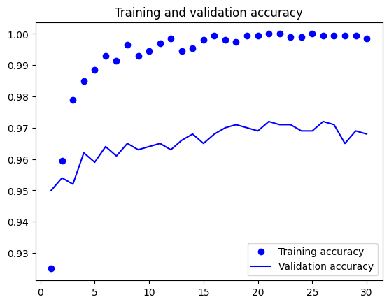

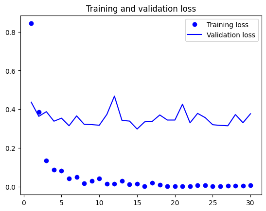

```python
accuracy = history_2.history["accuracy"]
val_accuracy = history_2.history["val_accuracy"]
loss = history_2.history["loss"]
val_loss = history_2.history["val_loss"]
epochs = range(1, len(accuracy) + 1)
plt.plot(epochs, accuracy, "bo", label="Training accuracy")
plt.plot(epochs, val_accuracy, "b", label="Validation accuracy")
plt.title("Training and validation accuracy")
plt.legend()
plt.figure()
plt.plot(epochs, loss, "bo", label="Training loss")
plt.plot(epochs, val_loss, "b", label="Validation loss")
plt.title("Training and validation loss")
plt.legend()
plt.show()
```

```python
best_model_2 = keras.models.load_model("./models/finetune-vgg16.keras")
best_model_2.summary()
```

```
Model: "functional_65"
```

[output not shown]

```
 Total params: 49,767,428 (189.85 MB)
```

```
 Trainable params: 24,883,713 (94.92 MB)
```

```
 Non-trainable params: 0 (0.00 B)
```

```
 Optimizer params: 24,883,715 (94.92 MB)
```

## 4 Explore the relative performance of the models

### 1 accuracy

```python
# Evaluate the performance of the best model on the test set
test_loss, test_acc = best_model_1.evaluate(x=test_features, y=test_labels)

# Print the test accuracy
print(f"Test accuracy: {test_acc:.3f}")
```

```
63/63 ━━━━━━━━━━━━━━━━━━━━ 1s 5ms/step - accuracy: 0.9679 - loss: 6.2752
Test accuracy: 0.974
```

```python
# Predict the labels for the test set using the best model
y_test_pred = best_model_1.predict(test_features)

# `y_test_pred` contains the predicted labels for the test set images.
# Each value in `y_test_pred` represents the model's confidence score for the corresponding class.
# For binary classification with sigmoid activation, values closer to 0 indicate class 0,
# and values closer to 1 indicate class 1.
# The threshold for class assignment can be adjusted based on the application's requirements.

# Here, `test_features` represent the input features of the test set.
# The predicted labels are obtained using the `predict` method of the best_model_1.

# Further analysis can be performed using `y_test_pred` to evaluate the model's performance
# and understand its behavior on the test set.
```

```
63/63 ━━━━━━━━━━━━━━━━━━━━ 0s 4ms/step
```

```python
y_test_pred
```

```
array([[1.],
       [1.],
       [1.],
       ...,
       [0.],
       [0.],
       [1.]], dtype=float32)
```

```python
# Convert the predicted probabilities to binary labels using a threshold of 0.5
y_test_pred_binary = (y_test_pred > 0.5).astype("int32").flatten()

# The `y_test_pred` contains predicted probabilities for each class.
# To obtain binary predictions, we apply a threshold of 0.5.
# If the predicted probability is greater than 0.5, the corresponding label is set to 1 (positive class).
# Otherwise, it is set to 0 (negative class).

# The `.astype("int32")` converts the boolean array into integers (0 or 1).
# Finally, `.flatten()` reshapes the array to a 1D vector for easy comparison with the true labels.
```

```python
# Store the true labels for the test set
test_labels = test_labels

# Convert the predicted probabilities to binary labels using a threshold of 0.5
y_test_pred_binary = (y_test_pred > 0.5).astype("int32").flatten()

# The `test_labels` variable holds the true labels for the test set.
# The `y_test_pred` variable contains the predicted probabilities for each instance in the test set.
# We use a threshold of 0.5 to convert these probabilities into binary predictions.
# If the predicted probability is greater than 0.5, the corresponding label is set to 1 (positive class).
# Otherwise, it is set to 0 (negative class).
# The resulting binary labels are stored in the `y_test_pred_binary` variable.
```

```python
from sklearn.metrics import accuracy_score

# Calculate the accuracy between true labels and predicted binary labels
accuracy = accuracy_score(test_labels, y_test_pred_binary)

# Print the calculated accuracy
print(f'Calculated Accuracy: {accuracy}')
```

```
Calculated Accuracy: 0.974
```

### Confusion Matrix

In this section of the code, we calculate the accuracy score and construct the confusion matrix. The confusion matrix is a table that describes the performance of a classification model on a set of test data for which the true values are known. It allows visualization of the performance of an algorithm and helps us understand how well the model is performing in terms of classifying different classes. The confusion matrix provides insights into the number of true positives, false positives, true negatives, and false negatives predicted by the model.

```
Confusion matrix:
 [[983  17]
 [ 35 965]]
```

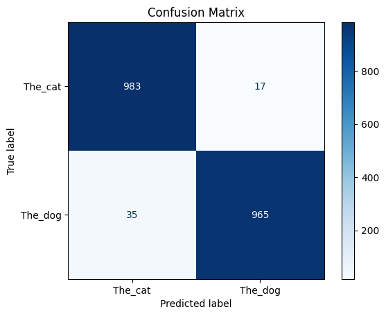

```python
from sklearn.metrics import ConfusionMatrixDisplay

# Calculate the confusion matrix
conf_mat = confusion_matrix(test_labels, y_test_pred_binary)

# Print the confusion matrix
print(f'Confusion matrix:\n {conf_mat}')

# Create ConfusionMatrixDisplay object with specified display labels
conf_mat_dis = ConfusionMatrixDisplay(conf_mat, display_labels=['The_cat', 'The_dog'])

# Plot the confusion matrix with specified title and color
conf_mat_dis.plot(cmap='Blues')  # Change the color of the plot
conf_mat_dis.ax_.set_title('Confusion Matrix')  # Set title for the plot

# Show the plot
plt.show()
```

### Precision, Recall and F1

In this section of the code, we calculate precision, recall, and F1-score using the classification_report function from scikit-learn. Precision measures the proportion of correctly predicted positive cases out of all cases predicted as positive. Recall, also known as sensitivity, measures the proportion of correctly predicted positive cases out of all actual positive cases. F1-score is the harmonic mean of precision and recall, providing a single score that balances both metrics.

The classification_report function generates a report containing precision, recall, and F1-score for each class, along with other metrics such as support (the number of true instances for each class). The report is then printed for analysis and interpretation.

```python
from sklearn.metrics import classification_report

# Generate classification report
report = classification_report(test_labels, y_test_pred_binary)

# Print classification report
print("Classification Report:\n", report)

# Convert classification report to DataFrame
report_df = pd.DataFrame(classification_report(test_labels, y_test_pred_binary, output_dict=True)).T
report_df
```

```
Classification Report:
               precision    recall  f1-score   support

           0       0.97      0.98      0.97      1000
           1       0.98      0.96      0.97      1000

    accuracy                           0.97      2000
   macro avg       0.97      0.97      0.97      2000
weighted avg       0.97      0.97      0.97      2000
```

|  | precision | recall | f1-score | support |
| --- | --- | --- | --- | --- |
| 0 | 0.965619 | 0.983 | 0.974232 | 1000.000 |
| 1 | 0.982688 | 0.965 | 0.973764 | 1000.000 |
| accuracy | 0.974000 | 0.974 | 0.974000 | 0.974 |
| macro avg | 0.974154 | 0.974 | 0.973998 | 2000.000 |
| weighted avg | 0.974154 | 0.974 | 0.973998 | 2000.000 |

### Precision Recall Curve

This section of the code computes the precision and recall values using the precision_recall_curve function from scikit-learn. The precision-recall curve is then plotted using matplotlib, with recall on the x-axis and precision on the y-axis. This curve visualizes the trade-off between precision and recall for different threshold values. A higher area under the curve indicates better model performance.

```python
from sklearn.metrics import precision_recall_curve

# Compute precision, recall, and thresholds
precision, recall, thresholds = precision_recall_curve(test_labels, y_test_pred.flatten())
```

```python
threshold = 0.8
```

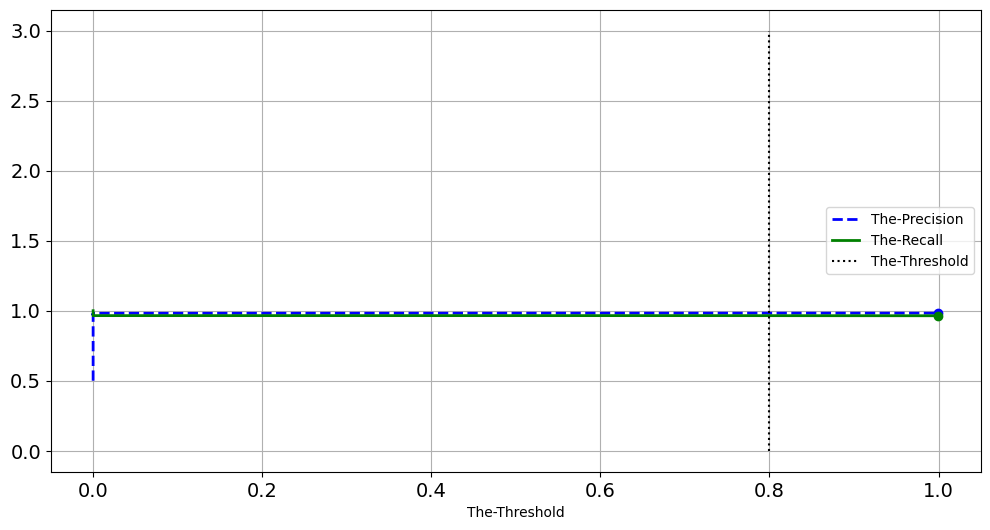

```python
import matplotlib.pyplot as plt

# Plot precision and recall curves
plt.figure(figsize=(12, 6))  # Set the figure size
plt.plot(thresholds, precision[:-1], "b--", label="The-Precision", linewidth=2)  # Precision curve
plt.plot(thresholds, recall[:-1], "g-", label="The-Recall", linewidth=2)  # Recall curve

# Plot vertical line at the selected threshold
plt.vlines(threshold, 0, 3.0, "k", "dotted", label="The-Threshold")
idx = (thresholds >= threshold).argmax()  # first index ≥ threshold
plt.plot(thresholds[idx], precision[idx], "bo")  # Plot precision point
plt.plot(thresholds[idx], recall[idx], "go")  # Plot recall point

# Set labels and legend
plt.xlabel("The-Threshold")
plt.legend(loc="center right")

# Customize grid and ticks
plt.grid(True)
plt.xticks(fontsize=14)  # Adjust x-axis tick font size
plt.yticks(fontsize=14)  # Adjust y-axis tick font size

# Show the plot
plt.show()
```

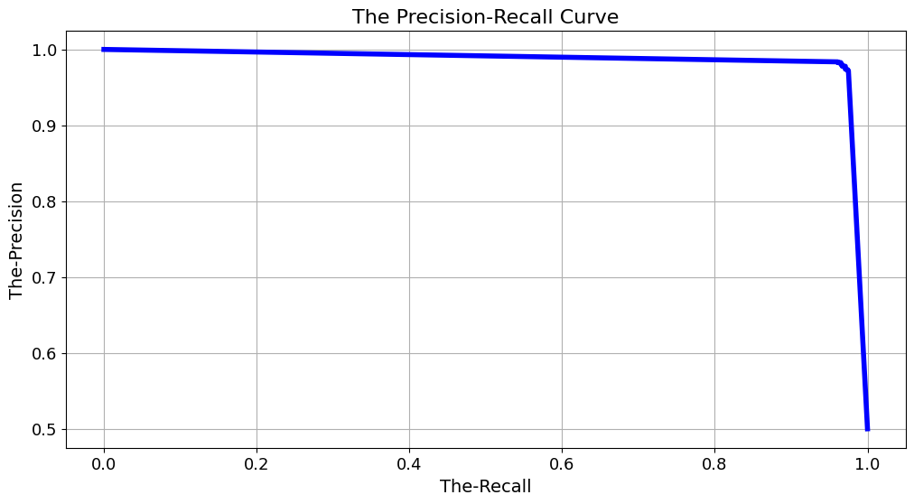

```python
import matplotlib.pyplot as plt

# Plot precision-recall curve
plt.figure(figsize=(12, 6))  # Set the figure size
plt.plot(recall, precision, "b-", linewidth=4)  # Plot precision-recall curve

# Set labels, title, and grid
plt.xlabel("The-Recall", fontsize=14)  # Set x-axis label with fontsize
plt.ylabel("The-Precision", fontsize=14)  # Set y-axis label with fontsize
plt.grid(True)  # Enable grid
plt.title('The Precision-Recall Curve', fontsize=16)  # Set plot title with fontsize

# Customize tick fontsize
plt.xticks(fontsize=13)  # Set x-axis tick fontsize
plt.yticks(fontsize=13)  # Set y-axis tick fontsize

# Show the plot
plt.show()
```

```python
import pandas as pd

# Create a DataFrame for predictions
predictions_df = pd.DataFrame({
    'Probability': y_test_pred.flatten().round(9),  # Predicted probabilities rounded to 6 decimal places
    'Predicted_Class': y_test_pred_binary,  # Predicted classes
    'Ground_Truth': test_labels  # Ground truth labels
})

# Display the predictions DataFrame
display(predictions_df)
```

|  | Probability | Predicted_Class | Ground_Truth |
| --- | --- | --- | --- |
| 0 | 1.0 | 1 | 1 |
| 1 | 1.0 | 1 | 1 |
| 2 | 1.0 | 1 | 1 |
| 3 | 0.0 | 0 | 0 |
| 4 | 0.0 | 0 | 0 |
| ... | ... | ... | ... |
| 1995 | 0.0 | 0 | 0 |
| 1996 | 1.0 | 1 | 1 |
| 1997 | 0.0 | 0 | 0 |
| 1998 | 0.0 | 0 | 0 |
| 1999 | 1.0 | 1 | 1 |

2000 rows × 3 columns

```python
# Filter rows where Predicted_Class does not match Ground_Truth
mismatch_df = predictions_df[predictions_df['Predicted_Class'] != predictions_df['Ground_Truth']]

# Display the mismatch DataFrame
display(mismatch_df)
```

|  | Probability | Predicted_Class | Ground_Truth |
| --- | --- | --- | --- |
| 11 | 1.000000e+00 | 1 | 0 |
| 58 | 0.000000e+00 | 0 | 1 |
| 84 | 0.000000e+00 | 0 | 1 |
| 133 | 0.000000e+00 | 0 | 1 |
| 167 | 0.000000e+00 | 0 | 1 |
| 207 | 0.000000e+00 | 0 | 1 |
| 214 | 0.000000e+00 | 0 | 1 |
| 222 | 1.000000e+00 | 1 | 0 |
| 236 | 0.000000e+00 | 0 | 1 |
| 275 | 0.000000e+00 | 0 | 1 |
| 279 | 1.000000e+00 | 1 | 0 |
| 286 | 0.000000e+00 | 0 | 1 |
| 294 | 9.999991e-01 | 1 | 0 |
| 314 | 1.000000e+00 | 1 | 0 |
| 319 | 1.000000e+00 | 1 | 0 |
| 320 | 0.000000e+00 | 0 | 1 |
| 332 | 0.000000e+00 | 0 | 1 |
| 375 | 0.000000e+00 | 0 | 1 |
| 450 | 0.000000e+00 | 0 | 1 |
| 534 | 0.000000e+00 | 0 | 1 |
| 552 | 1.000000e+00 | 1 | 0 |
| 563 | 0.000000e+00 | 0 | 1 |
| 591 | 1.000000e+00 | 1 | 0 |
| 610 | 0.000000e+00 | 0 | 1 |
| 633 | 1.000000e+00 | 1 | 0 |
| 652 | 0.000000e+00 | 0 | 1 |
| 679 | 0.000000e+00 | 0 | 1 |
| 749 | 1.000000e+00 | 1 | 0 |
| 831 | 0.000000e+00 | 0 | 1 |
| 842 | 0.000000e+00 | 0 | 1 |
| 906 | 1.000000e+00 | 1 | 0 |
| 929 | 3.570000e-07 | 0 | 1 |
| 1027 | 0.000000e+00 | 0 | 1 |
| 1072 | 0.000000e+00 | 0 | 1 |
| 1164 | 0.000000e+00 | 0 | 1 |
| 1207 | 0.000000e+00 | 0 | 1 |
| 1236 | 1.000000e+00 | 1 | 0 |
| 1329 | 0.000000e+00 | 0 | 1 |
| 1343 | 1.000000e+00 | 1 | 0 |
| 1349 | 1.000000e+00 | 1 | 0 |
| 1374 | 3.080000e-07 | 0 | 1 |
| 1406 | 1.000000e+00 | 1 | 0 |
| 1505 | 1.000000e+00 | 1 | 0 |
| 1540 | 0.000000e+00 | 0 | 1 |
| 1577 | 0.000000e+00 | 0 | 1 |
| 1585 | 0.000000e+00 | 0 | 1 |
| 1654 | 0.000000e+00 | 0 | 1 |
| 1796 | 0.000000e+00 | 0 | 1 |
| 1864 | 1.000000e+00 | 1 | 0 |
| 1882 | 0.000000e+00 | 0 | 1 |
| 1911 | 0.000000e+00 | 0 | 1 |
| 1965 | 0.000000e+00 | 0 | 1 |

```python
len(mismatch_df)
```

```
52
```

We have identified 52 cases where our model incorrectly predicted the labels on our test dataset. This suggests instances where the predicted class does not match the actual class (ground truth) according to our model. These cases represent potential misclassifications that warrant further investigation to understand why the model made incorrect predictions.